# **Unsupervised Learning Project: AllLife Bank Customer Segmentation**

## **Gaussian Mixture Model**

Let's now create clusters using the Gaussian Mixture Model.

- Apply the Gaussian Mixture Model algorithm on the pca components

```python
gmm = GaussianMixture(n_components = 3, random_state = 1)

gmm.fit(transformed_data)

data_scaled_copy['GmmLabels'] = gmm.predict(transformed_data)

data['GmmLabels'] = gmm.predict(transformed_data)
transformed_data['GmmLabels'] = gmm.predict(transformed_data)
```

```python
data.GmmLabels.value_counts()
```

```
1    380
0    226
2     49
Name: GmmLabels, dtype: int64
```

Identical numbers for each cluster indicates that we've likely made the exact same split as with KMeans

#### **Creating the cluster profiles using the summary statistics and box plots for each label**

```python
mean = data.groupby('GmmLabels').mean()

median = data.groupby('GmmLabels').median()

df_gmm = pd.concat([mean, median], axis = 0)

df_gmm.index = ['group_0 Mean', 'group_1 Mean', 'group_2 Mean', 'group_0 Median', 'group_1 Median', 'group_2 Median']

df_gmm[cols_visualise].T
```

|  | group_0 Mean | group_1 Mean | group_2 Mean | group_0 Median | group_1 Median | group_2 Median |
| --- | --- | --- | --- | --- | --- | --- |
| Sl_No | 115.460177 | 420.434211 | 610.836735 | 115.5 | 420.5 | 636.0 |
| Avg_Credit_Limit | 12831.858407 | 33326.315789 | 140102.040816 | 12000.0 | 31000.0 | 145000.0 |
| Total_Credit_Cards | 2.433628 | 5.507895 | 8.775510 | 2.0 | 6.0 | 9.0 |
| Total_visits_bank | 0.929204 | 3.510526 | 0.591837 | 1.0 | 3.0 | 1.0 |
| Total_visits_online | 3.535398 | 0.973684 | 10.979592 | 4.0 | 1.0 | 11.0 |
| Total_calls_made | 6.827434 | 2.005263 | 1.102041 | 7.0 | 2.0 | 1.0 |

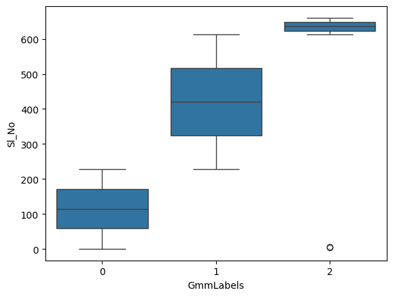

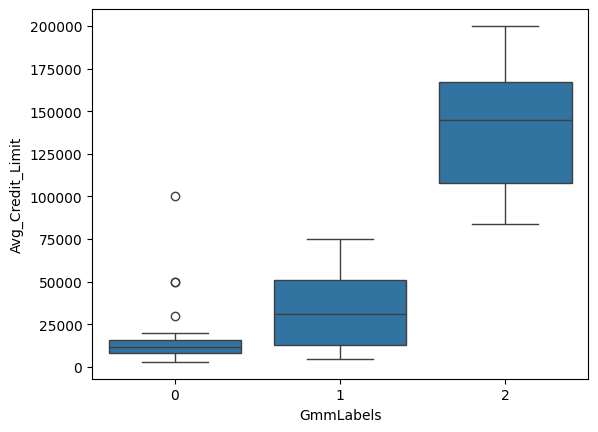

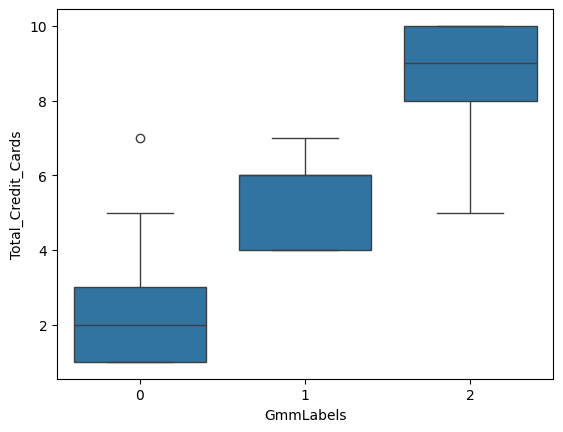

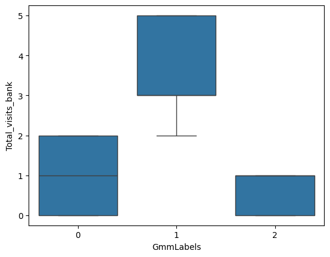

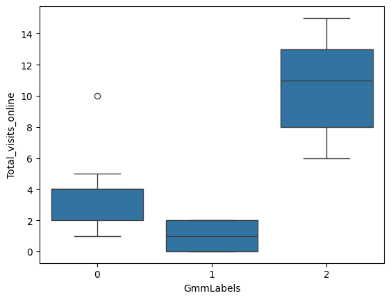

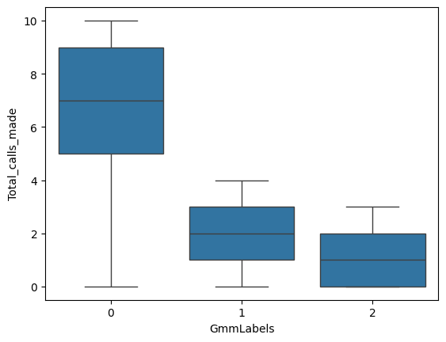

```python
for col in cols_visualise:
    sns.boxplot(x = 'GmmLabels', y = col, data = data)

    plt.show()
```

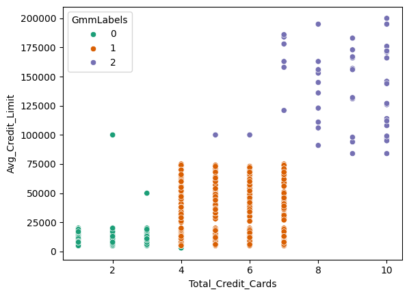

```python
sns.scatterplot(y='Avg_Credit_Limit', x='Total_Credit_Cards', data=data, hue='GmmLabels', palette='Dark2')
```

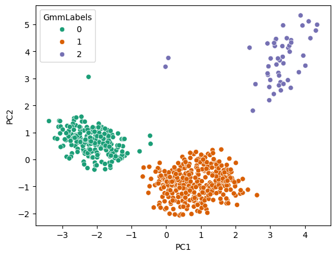

```python
sns.scatterplot(y='PC2', x='PC1', data=transformed_data, hue='GmmLabels', palette='Dark2')
```

#### **Compare the clusters from both algorithms - K-means and Gaussian Mixture Model**

**Comparing Clusters** They seem identical to KMeans, right down to the erant data point of the second of 3 clusters showing 4 credit cards and the lowest credit limit.

## **K-Medoids**

- Apply the K-Medoids clustering algorithm on the pca components

```python
kmedo = KMedoids(n_clusters = 3, random_state = 5)

kmedo.fit(transformed_data)

data_scaled_copy['kmedoLabels'] = kmedo.predict(transformed_data)

data['kmedoLabels'] = kmedo.predict(transformed_data)
transformed_data['kmedoLabels']=kmedo.predict(transformed_data)
```

```python
data.kmedoLabels.value_counts()
```

```
1    234
2    228
0    193
Name: kmedoLabels, dtype: int64
```

Well that's certainly a departure from KMeans and Gaussia Mixture's results of 380, 226, 49. Let's see what they are:

#### **Create cluster profiles using the summary statistics and box plots for each label**

```python
mean = data.groupby('kmedoLabels').mean()

median = data.groupby('kmedoLabels').median()

df_kmedoids = pd.concat([mean, median], axis = 0)

df_kmedoids.index = ['group_0 Mean', 'group_1 Mean', 'group_2 Mean', 'group_0 Median', 'group_1 Median', 'group_2 Median']

df_kmedoids[cols_visualise].T
```

|  | group_0 Mean | group_1 Mean | group_2 Mean | group_0 Median | group_1 Median | group_2 Median |
| --- | --- | --- | --- | --- | --- | --- |
| Sl_No | 330.865285 | 537.722222 | 114.500000 | 325.0 | 542.0 | 114.5 |
| Avg_Credit_Limit | 15549.222798 | 69777.777778 | 13596.491228 | 13000.0 | 58500.0 | 12000.0 |
| Total_Credit_Cards | 5.331606 | 6.337607 | 2.460526 | 5.0 | 6.0 | 2.0 |
| Total_visits_bank | 3.575130 | 2.876068 | 0.921053 | 4.0 | 3.0 | 1.0 |
| Total_visits_online | 1.010363 | 2.948718 | 3.605263 | 1.0 | 1.0 | 4.0 |
| Total_calls_made | 1.870466 | 1.923077 | 6.789474 | 2.0 | 2.0 | 7.0 |

**Cluster Profiles:**

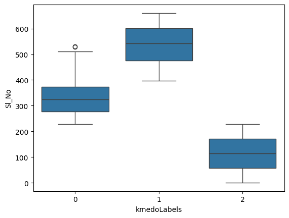

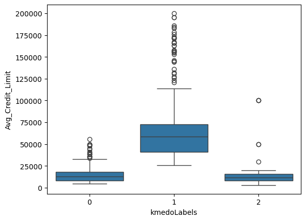

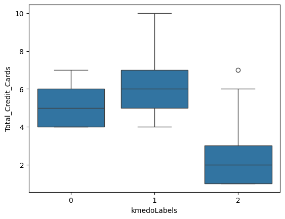

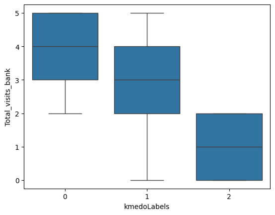

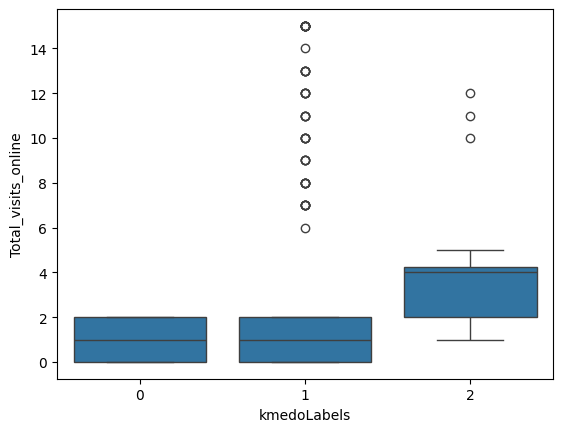

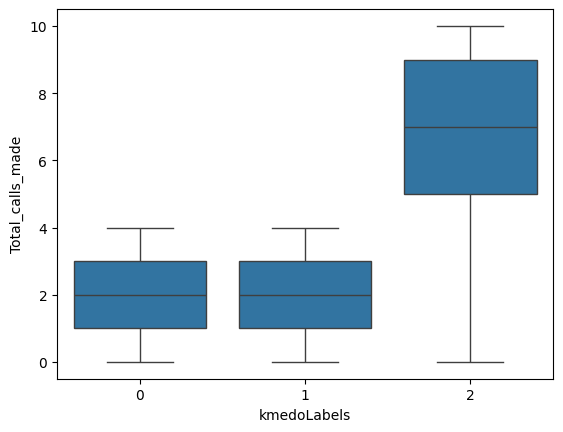

```python
for col in cols_visualise:
    sns.boxplot(x = 'kmedoLabels', y = col, data = data)

    plt.show()
```

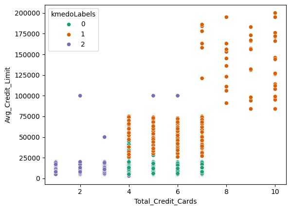

```python
sns.scatterplot(y='Avg_Credit_Limit', x='Total_Credit_Cards', data=data, hue='kmedoLabels', palette='Dark2')
```

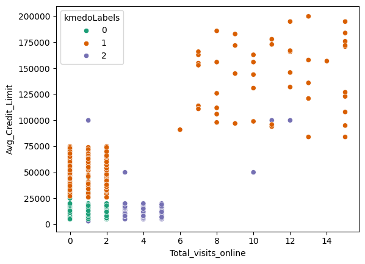

```python
sns.scatterplot(y='Avg_Credit_Limit', x='Total_visits_online', data=data, hue='kmedoLabels', palette='Dark2')
```

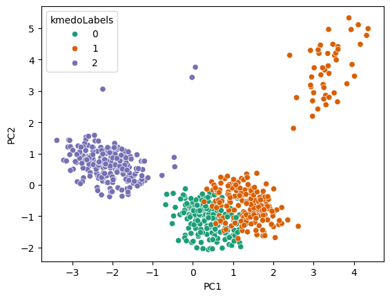

```python
sns.scatterplot(y='PC2', x='PC1', data=transformed_data, hue='kmedoLabels', palette='Dark2')
```

#### **Compare the clusters from K-Means and K-Medoids**

Let's check out the silhouette score and compared to 0.53, obtained with KMeans.

```python
kmedoLabels = kmedo.predict(data_scaled)
print(silhouette_score(data_scaled, kmedoLabels))
```

```
0.22955053307399242
```

Silhouette score confirms what already seems obvious from visual inspection. N.b. I have attempted to initialize Kmedoids with different random states and the results in this latest plot seem robust to different initializations.

#### **Conclusions and Recommendations**

*Based on this input, the marketing team proposes to run personalized campaigns to target new customers as well as upsell to existing customers.*

*...customers perceive the support services of the bank poorly. Based on this, the operations team wants to upgrade the service delivery model, to ensure that customers' queries are resolved faster.*

- My first recommendation would be to understand the nature of the Customer Serial Number, as it already seems to embed a great deal of clustering information that data engineers may be able to shed light on.
- Regarding the targeting of new customers,
  - I would venture to guess that **Group 0**, with their larger amount of phone contact would be an older segment of the population or who otherwise does not have easy broadband access (worth cross-referencing with any available demographic data). This group should be targeted accordingly and the bank's positive performance with phone support should be emphasized (e.g. "Typical hold times less than 5 minutes. You'll get a person on the other end of the line, who *cares* about you.")
  - **Group 1** comes into the bank physically a lot more so these may be those who simply live or work close to a physical branch. These potential customers can likely be reached with physical ads such as billboards, bus and subway signs.
  - **Group 2** is the likely high-powered young professionals, who consistently use online services for their heavy credit card use and high number of cards. This group can be reached via online ads in Instagram or even Tik Tok.

  Perhaps most usefully, customer dissatisfaction data should be collected to determine which group needs to be most catered to and focus efforts on that medium specifically to maximize cost effectivness of the intervention. E.g. if the only customers who are dissatisfied fit clearly into Group 1, hire more tellers; if dissatisfied customers are from Group 2, invest in redesigning or otherwise improving the website; if from Group 0, hire more phone operators.